# hw2

## Question 5.1

Using crime data from the file uscrime.txt (http://www.statsci.org/data/general/uscrime.txt, description at http://www.statsci.org/data/general/uscrime.html), test to see whether there are any outliers in the last column (number of crimes per 100,000 people). Use the grubbs.test function in the outliers package in R.

### Grubbs test

```r
library(outliers)
x = read.table("/ashokholla/Georgia\ Tech/Assignments/ISYE-6501/week3/uscrime.txt", header = TRUE)
head(x)
```

```
##      M So   Ed  Po1  Po2    LF   M.F Pop   NW    U1  U2 Wealth Ineq     Prob
## 1 15.1  1  9.1  5.8  5.6 0.510  95.0  33 30.1 0.108 4.1   3940 26.1 0.084602
## 2 14.3  0 11.3 10.3  9.5 0.583 101.2  13 10.2 0.096 3.6   5570 19.4 0.029599
## 3 14.2  1  8.9  4.5  4.4 0.533  96.9  18 21.9 0.094 3.3   3180 25.0 0.083401
## 4 13.6  0 12.1 14.9 14.1 0.577  99.4 157  8.0 0.102 3.9   6730 16.7 0.015801
## 5 14.1  0 12.1 10.9 10.1 0.591  98.5  18  3.0 0.091 2.0   5780 17.4 0.041399
## 6 12.1  0 11.0 11.8 11.5 0.547  96.4  25  4.4 0.084 2.9   6890 12.6 0.034201
##      Time Crime
## 1 26.2011   791
## 2 25.2999  1635
## 3 24.3006   578
## 4 29.9012  1969
## 5 21.2998  1234
## 6 20.9995   682
```

```r
summary(x)
```

```
##        M               So               Ed             Po1
##  Min.   :11.90   Min.   :0.0000   Min.   : 8.70   Min.   : 4.50
##  1st Qu.:13.00   1st Qu.:0.0000   1st Qu.: 9.75   1st Qu.: 6.25
##  Median :13.60   Median :0.0000   Median :10.80   Median : 7.80
##  Mean   :13.86   Mean   :0.3404   Mean   :10.56   Mean   : 8.50
##  3rd Qu.:14.60   3rd Qu.:1.0000   3rd Qu.:11.45   3rd Qu.:10.45
##  Max.   :17.70   Max.   :1.0000   Max.   :12.20   Max.   :16.60
##       Po2               LF              M.F              Pop
##  Min.   : 4.100   Min.   :0.4800   Min.   : 93.40   Min.   :  3.00
##  1st Qu.: 5.850   1st Qu.:0.5305   1st Qu.: 96.45   1st Qu.: 10.00
##  Median : 7.300   Median :0.5600   Median : 97.70   Median : 25.00
##  Mean   : 8.023   Mean   :0.5612   Mean   : 98.30   Mean   : 36.62
##  3rd Qu.: 9.700   3rd Qu.:0.5930   3rd Qu.: 99.20   3rd Qu.: 41.50
##  Max.   :15.700   Max.   :0.6410   Max.   :107.10   Max.   :168.00
##        NW              U1                U2            Wealth
##  Min.   : 0.20   Min.   :0.07000   Min.   :2.000   Min.   :2880
##  1st Qu.: 2.40   1st Qu.:0.08050   1st Qu.:2.750   1st Qu.:4595
##  Median : 7.60   Median :0.09200   Median :3.400   Median :5370
##  Mean   :10.11   Mean   :0.09547   Mean   :3.398   Mean   :5254
##  3rd Qu.:13.25   3rd Qu.:0.10400   3rd Qu.:3.850   3rd Qu.:5915
##  Max.   :42.30   Max.   :0.14200   Max.   :5.800   Max.   :6890
##       Ineq            Prob              Time           Crime
##  Min.   :12.60   Min.   :0.00690   Min.   :12.20   Min.   : 342.0
##  1st Qu.:16.55   1st Qu.:0.03270   1st Qu.:21.60   1st Qu.: 658.5
##  Median :17.60   Median :0.04210   Median :25.80   Median : 831.0
##  Mean   :19.40   Mean   :0.04709   Mean   :26.60   Mean   : 905.1
##  3rd Qu.:22.75   3rd Qu.:0.05445   3rd Qu.:30.45   3rd Qu.:1057.5
##  Max.   :27.60   Max.   :0.11980   Max.   :44.00   Max.   :1993.0
```

```r
crime<- x[,16]
```

A p-value less than 0.05 (typically ≤ 0.05) is statistically significant. … A p-value higher than 0.05 (> 0.05) is not statistically significant and indicates weak evidence against the null hypothesis. This means we fail to reject the null hypothesis and cannot accept the alternative hypothesis

```r
grubbs.test(crime) #Default
```

```
##
##  Grubbs test for one outlier
##
## data:  crime
## G = 2.81287, U = 0.82426, p-value = 0.07887
## alternative hypothesis: highest value 1993 is an outlier
```

p-value > 0.05 we fail to reject the null hypothesis, i.e. 1993 is not an outlier, hence we cannot accept the alternative hypothesis

```r
grubbs.test(crime, two.sided = TRUE) #Default
```

```
##
##  Grubbs test for one outlier
##
## data:  crime
## G = 2.81287, U = 0.82426, p-value = 0.1577
## alternative hypothesis: highest value 1993 is an outlier
```

p-value > 0.05 we fail to reject the null hypothesis, i.e. 1993 is not an outlier, hence we cannot accept the alternative hypothesis

```r
grubbs.test(crime, opposite = TRUE) #Default
```

```
##
##  Grubbs test for one outlier
##
## data:  crime
## G = 1.45589, U = 0.95292, p-value = 1
## alternative hypothesis: lowest value 342 is an outlier
```

p-value > 0.05 we fail to reject the null hypothesis, i.e. 342 is not an outlier, hence we cannot accept the alternative hypothesis

```r
grubbs.test(crime, type=11) # lowest and highest
```

```
##
##  Grubbs test for two opposite outliers
##
## data:  crime
## G = 4.26877, U = 0.78103, p-value = 1
## alternative hypothesis: 342 and 1993 are outliers
```

p-value > 0.05 we fail to reject the null hypothesis, i.e. 342 and 1993 are not outliers, hence we cannot accept the alternative hypothesis

```r
grubbs.test(crime, type=11, opposite = TRUE) #
```

```
##
##  Grubbs test for two opposite outliers
##
## data:  crime
## G = 4.26877, U = 0.78103, p-value = 1
## alternative hypothesis: 342 and 1993 are outliers
```

p-value > 0.05 we fail to reject the null hypothesis, i.e. 342 and 1993 are not outliers, hence we cannot accept the alternative hypothesis

Since we failed to reject the null hypothesis in all the above grubbs test, we can say that there are no outliers in the Crime data, as per grubbs test

### Boxplot

Lets look at the data using boxplot.

```r
boxplot.stats(crime)
```

```
## $stats
## [1]  342.0  658.5  831.0 1057.5 1635.0
##
## $n
## [1] 47
##
## $conf
## [1] 739.0438 922.9562
##
## $out
## [1] 1969 1674 1993
```

Per boxplot.stats

The outliers are 1674, 1969, 1993

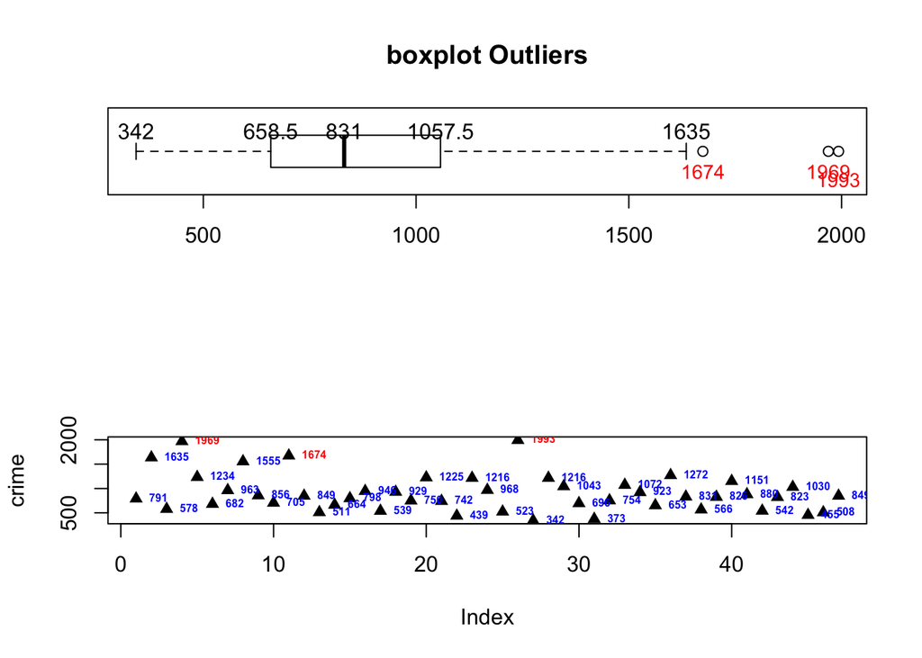

```r
#Lets look them using boxplot

library(graphics)

# set up a layout for plotting
#mat <- matrix(c(1,2,3), nrow=3, ncol=1)

#layout(mat)
par(mfcol=c(2,1))

boxplot(crime, main="boxplot Outliers", staplewax=1,horizontal = TRUE)
text(x=boxplot.stats(crime)$stats, labels = boxplot.stats(crime)$stats, y = 1.25)
text(x=boxplot.stats(crime)$out[1:2], labels = boxplot.stats(crime)$out[1:2], y=0.75, col="red", cex=0.9)
text(x=boxplot.stats(crime)$out[3], labels = boxplot.stats(crime)$out[3], y=0.65, col="red", cex=0.9)
plot(crime, pch=17)
text(crime, labels=crime, cex=0.5, font=2,pos=4, col=ifelse(crime %in% boxplot.stats(crime)$out,"red", "blue"))
```

## Question 6.1

Describe a situation or problem from your job, everyday life, current events, etc., for which a Change Detection model would be appropriate. Applying the CUSUM technique, how would you choose the critical value and the threshold?

I hike every weekend and the terrain is pretty much the same (different mountains but similar distance and altitude). I’d use CUSUM to detect any change in my rythm/stamina/performance over the last few months. I will be detecting an increase in time taken so CUSUM for detecting an increase will be my approach. On an average if I take 60 mins for a 3 mile hike, I’d expect to be within 5 mins of my average, so my Threshold would be 6 The Critical value in this case will be a number much less than the difference between my data point and the mean (60 min/hike), which is normally 0<=n<=5. So 2 seems to be a good value to start with.

## Question 6.2

1. Using July through October daily-high-temperature data for Atlanta for 1996 through 2015, use
- CUSUM approach to identify when unofficial summer ends (i.e., when the weather starts cooling off) each year. You can get the data that you need from the file temps.txt or online, for example at http://www.iweathernet.com/atlanta-weather-records or https://www.wunderground.com/history/airport/KFTY/2015/7/1/CustomHistory.html . You can use R if you’d like, but it’s straightforward enough that an Excel spreadsheet can easily do the job too.
- Use a CUSUM approach to make a judgment of whether Atlanta’s summer climate has gotten warmer in that time (and if so, when).

### Read data and calculate the mean, standard deviation for summer months

```r
#Read Data
weatherdata<- read.table("/Georgia\ Tech/Assignments/ISYE-6501/week3/temps.txt", header = TRUE)
head(weatherdata)
```

```
##     DAY X1996 X1997 X1998 X1999 X2000 X2001 X2002 X2003 X2004 X2005 X2006 X2007
## 1 1-Jul    98    86    91    84    89    84    90    73    82    91    93    95
## 2 2-Jul    97    90    88    82    91    87    90    81    81    89    93    85
## 3 3-Jul    97    93    91    87    93    87    87    87    86    86    93    82
## 4 4-Jul    90    91    91    88    95    84    89    86    88    86    91    86
## 5 5-Jul    89    84    91    90    96    86    93    80    90    89    90    88
## 6 6-Jul    93    84    89    91    96    87    93    84    90    82    81    87
##   X2008 X2009 X2010 X2011 X2012 X2013 X2014 X2015
## 1    85    95    87    92   105    82    90    85
## 2    87    90    84    94    93    85    93    87
## 3    91    89    83    95    99    76    87    79
## 4    90    91    85    92    98    77    84    85
## 5    88    80    88    90   100    83    86    84
## 6    82    87    89    90    98    83    87    84
```

```r
#Calculate the mean for the summer months July, August and 15 days of september first 77 rows
weathermeans<-colMeans(weatherdata[1:77,-1])
summermean<-mean(weathermeans)

#mean of the autumn months
sep15_oct_means<-colMeans(weatherdata[77:123,-1])
mean(sep15_oct_means)
```

```
## [1] 75.77553
```

```r
#Calculate the standard deviation for the summer months July, August and 15 days of september first 77 rows
Sdmatrix<- apply(weatherdata[1:77,-1],2,sd)
Sdmatrix
```

```
##    X1996    X1997    X1998    X1999    X2000    X2001    X2002    X2003
## 4.849759 4.330936 3.967184 5.356977 7.006271 3.666972 4.547689 3.795256
##    X2004    X2005    X2006    X2007    X2008    X2009    X2010    X2011
## 4.422609 3.735533 5.302664 6.197204 3.736173 4.835044 3.583493 5.682804
##    X2012    X2013    X2014    X2015
## 5.614495 5.025057 3.669255 4.677903
```

```r
meanSd<-mean(Sdmatrix)

# Average SD for Fall months
mean(apply(weatherdata[77:123,-1],2,sd))
```

```
## [1] 7.485171
```

we are trying to find when unofficial summer ends,i.e. decreasing change, so St=max(0,S{t-1}+(mu-xt-C))

```r
#Calculate Xt-Mu for every year
xt_mu<-apply(weatherdata[,-1],1,'-',weathermeans)

#reverse signs i.e. mu-Xt since we are tracking decrease
mu_xt <- (apply(xt_mu,1,'*',-1))

#Lets set C = 0.5 of SD
C<-Sdmatrix*0.5

# subract C
mu_xt_c <-apply(mu_xt,1,'-',C)
mu_xt_c<-t(mu_xt_c)

#dimensions of the matrix for declaring St matrix
m<-dim(mu_xt)[1]
n<-dim(mu_xt)[2]
```

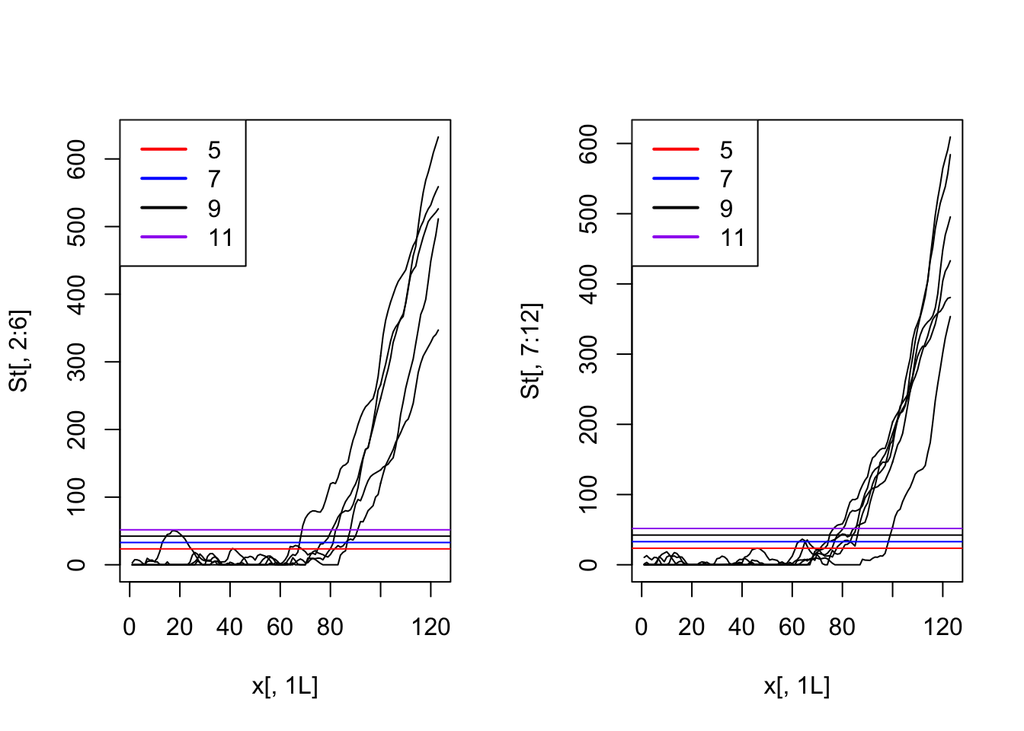

```r
#St matrix declaration
St<-matrix(rep(0),nrow=m,ncol=n)

#Calculate St, cusum
for( j in 1:n){
  St_1<-0
  for(i in 1:m){
    St_1<- max(0,St_1+as.numeric(mu_xt_c[i,j]))
    St[i,j]<-St_1
  }
}

#set column names and also append the "day of the month" information
colnames(St)<-colnames(weatherdata[,-1])
St<-cbind(as.matrix(weatherdata[,1]),St)

colnames(St)[1] <- "Day"

#Lets plot the values of St and try few Threshold values
Threshold<-c(meanSd*5,meanSd*7,meanSd*9,meanSd*11)
colnamThreshold<-c("5","7","9","11")
colorv<-c("red","blue","black","purple")


par(mfcol=c(1,2))

#1996-2000
matplot(y = St[,2:6], type = 'l', lty = 1, col = "black")
for(i in 1:length(Threshold)) {
abline(Threshold[i],0,col=colorv[i])
}
legend(legend = colnamThreshold, x = "topleft", y = "topleft", lty = 1, lwd = 2, col = colorv)



#2000-2005
matplot(y = St[,7:12], type = 'l', lty = 1, col = "black")
for(i in 1:length(Threshold)) {
abline(Threshold[i],0,col=colorv[i])
}
legend(legend = colnamThreshold, x = "topleft", y = "topleft", lty = 1, lwd = 2, col = colorv)
```

Based on the graphs above a Threshold of 7*Standard Deviation seems to detect the change effectively

```r
Thold<-(Sdmatrix * 7)
# Thresholds for each year
Thold
```

```
##    X1996    X1997    X1998    X1999    X2000    X2001    X2002    X2003
## 33.94831 30.31655 27.77029 37.49884 49.04390 25.66881 31.83382 26.56679
##    X2004    X2005    X2006    X2007    X2008    X2009    X2010    X2011
## 30.95826 26.14873 37.11865 43.38042 26.15321 33.84531 25.08445 39.77963
##    X2012    X2013    X2014    X2015
## 39.30147 35.17540 25.68478 32.74532
```

```r
#Find unofficial summer ends for each year
summermat<-matrix(nrow=2,ncol=n)
dim(summermat)
```

```
## [1]  2 20
```

```r
colnames(summermat)<-colnames(weatherdata[,-1])

#recalculate the dimensions
ms<-dim(St)[1]
ns<-dim(St)[2]

#Find the tip-over point i.e. the change in temperature for every year
# go column by column, i.e. year by year
for (j in 2:ns){

# go row by row, i.e. day by day
  for(i in 1:ms){
    dayVal<-as.numeric(St[i,j])
    Th<-Thold[j-1]
    if( dayVal > Th ) {

      summermat[1,j-1]<- St[i,1]
      summermat[2,j-1]<- weatherdata[i,j]
      break
    }

  }
}
```

```r
 # When Summer unofficially ends
summermat<-t(summermat)
colnames(summermat)<-c("Day","Temperature")
summermat
```

```
##       Day      Temperature
## X1996 "16-Sep" "82"
## X1997 "25-Sep" "66"
## X1998 "21-Sep" "82"
## X1999 "14-Jul" "81"
## X2000 "7-Sep"  "66"
## X2001 "3-Sep"  "73"
## X2002 "1-Sep"  "84"
## X2003 "10-Sep" "79"
## X2004 "15-Sep" "73"
## X2005 "6-Oct"  "72"
## X2006 "13-Sep" "70"
## X2007 "19-Sep" "82"
## X2008 "27-Aug" "80"
## X2009 "3-Sep"  "79"
## X2010 "28-Sep" "76"
## X2011 "7-Sep"  "69"
## X2012 "13-Sep" "81"
## X2013 "17-Aug" "66"
## X2014 "23-Sep" "77"
## X2015 "13-Sep" "75"
```

- Use a CUSUM approach to make a judgment of whether Atlanta’s summer climate has gotten warmer in that time (and if so, when). Here we are detecting an increase summer temperature over the years

```r
#Calculate the mean temperature for summer months across all years
summermean<-mean(weathermeans)
xt_mu<-apply(as.matrix(weathermeans),1,'-',summermean)
#Calculate the standard deviation for summer months across all years
sd<-mean(apply(as.matrix(weathermeans),2,sd))

sd
```

```
## [1] 1.86771
```

```r
Thhold <- sd*1.5
C<-(sd)*0.2

C
```

```
## [1] 0.3735419
```

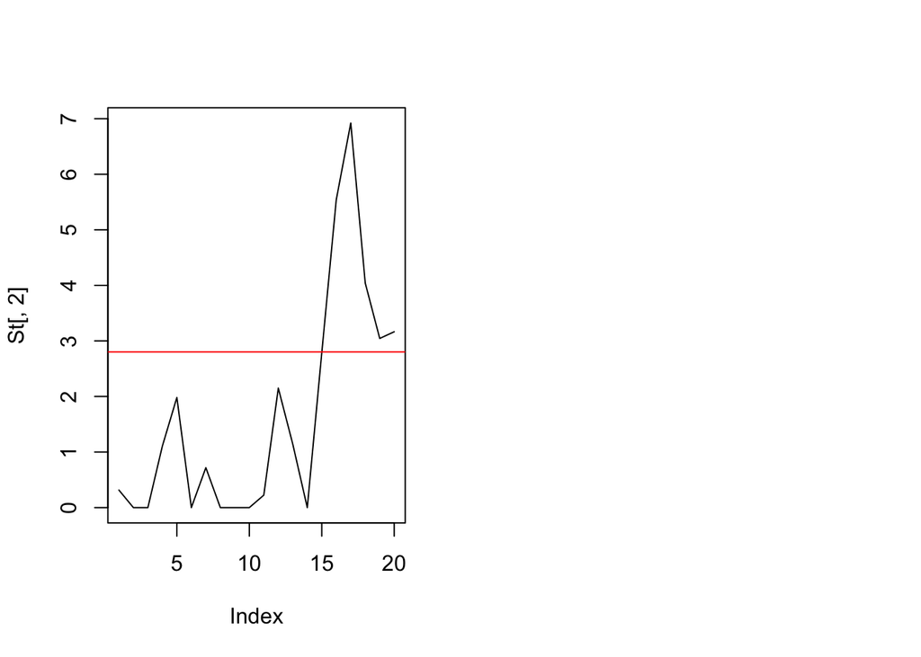

```r
#calculate Xt-mu-C
xt_mu_c <-as.matrix(apply(as.matrix(xt_mu),1,'-',C))


m<-dim(xt_mu_c)[1]
n<-dim(xt_mu_c)[2]

#St matrix
St<-matrix(rep(0),nrow=m,ncol=n)

#Calculate St
for( j in 1:n){
  St_1<-0
  for(i in 1:m){
    St_1<- max(0,St_1+as.numeric(xt_mu_c[i,j]))
    St[i,j]<-St_1
  }
}

#Set column names
St<-cbind(names(weathermeans),St)

#Plot to check of the threshold is good enough
par(mfcol=c(1,2))

plot(St[,2],type='l')
abline(Thhold,0,col="red")
```

```r
# Calculate the tipping year

for(i in 1:dim(St)[1]){
  if(St[i,2] > Thhold){
      print("Year when the temperature tipped")
    print(St[i,1])
        break
  }
}
```

```
## [1] "Year when the temperature tipped"
## [1] "X2011"
```

```r
#Average temperature before and after tipping point

print("Before")
```

```
## [1] "Before"
```

```r
mean(weathermeans[1:11])
```

```
## [1] 87.50767
```

```r
print("After")
```

```
## [1] "After"
```

```r
mean(weathermeans[12:20])
```

```
## [1] 88.51371
```

Based on the above averages and the cusum verification we can conclude Atlanta summers have been getting warmer